# ggplot2

## Coordinate systems

坐标系可能是ggplot2中最复杂的部分。 默认坐标系是笛卡尔坐标系，其中可以对x和y位置独立地进行操作，以查找每个点的位置。 我们也偶尔会使用到一些其他类型的坐标系。

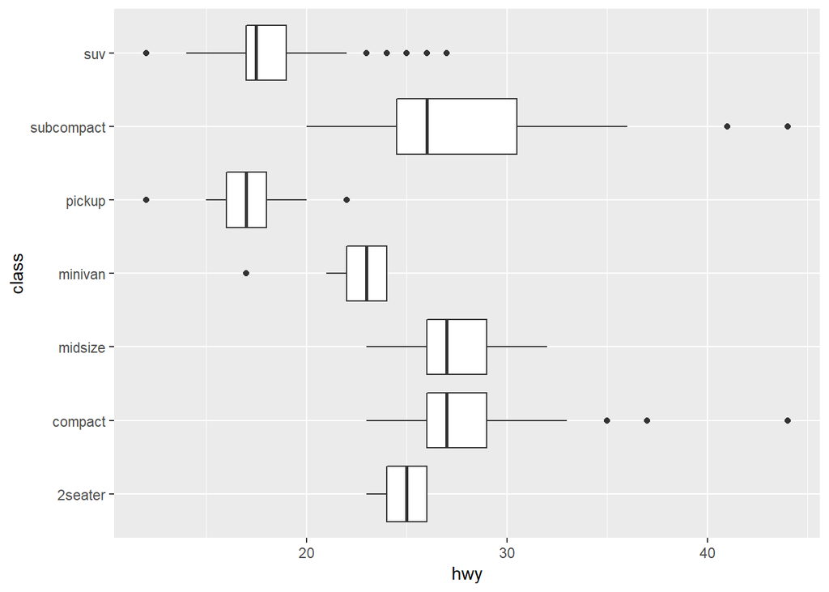

```r
ggplot(data = mpg, mapping = aes(x = class, y = hwy)) +

  geom_boxplot() +

  coord_flip()
```

coord_polar（）函数可以使用极坐标。 极坐标向我们展示了条形图和Coxcomb图之间的关系。

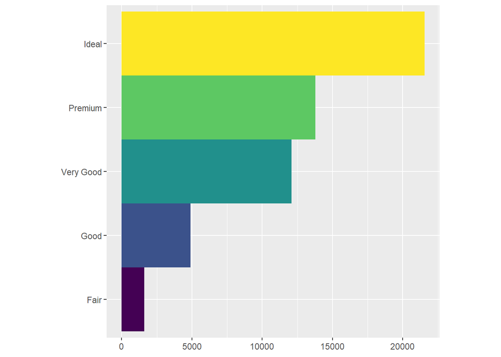

```r
bar <- ggplot(data = diamonds) +
  geom_bar(
    mapping = aes(x = cut, fill = cut),
    show.legend = FALSE,
    width = 1
  ) +
  theme(aspect.ratio = 1) +
  labs(x = NULL, y = NULL)
bar + coord_flip()
```

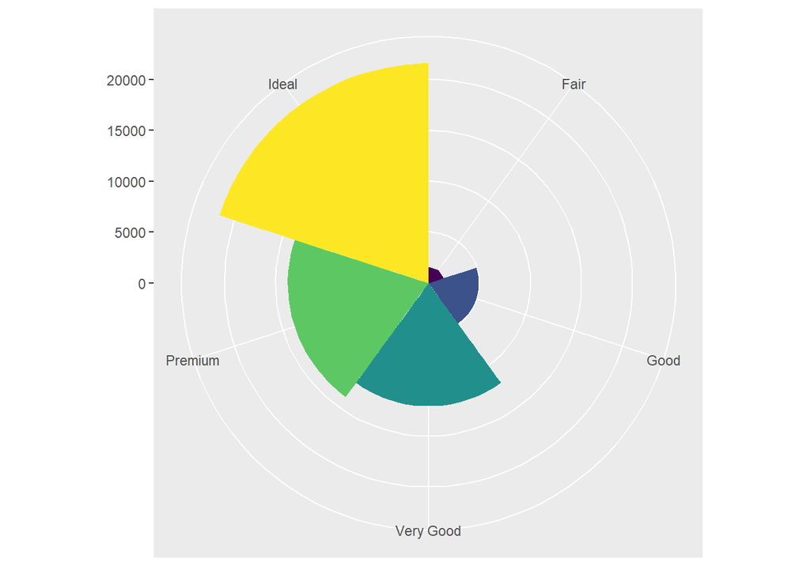

```r
bar + coord_polar()
```

### show.legend

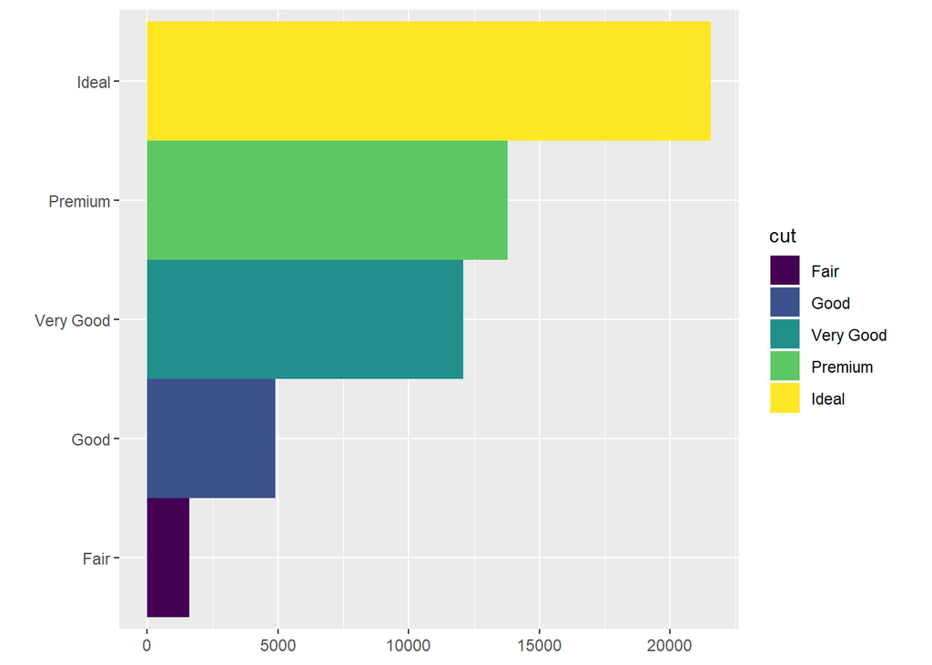

```r
bar <- ggplot(data = diamonds) +
  geom_bar(
    mapping = aes(x = cut, fill = cut),
    show.legend = TRUE,
    width = 1
  ) +
  theme(aspect.ratio = 1) +
  labs(x = NULL, y = NULL)
bar + coord_flip()
```

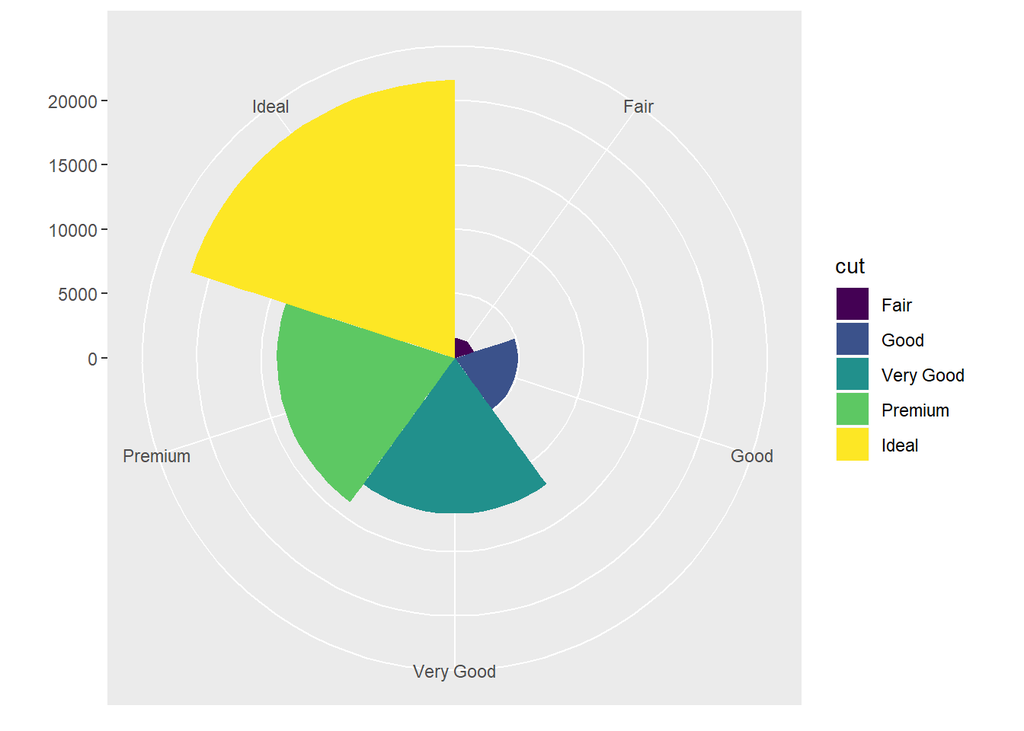

```r
bar + coord_polar()
```

## The layered grammar of graphics

总结：我们在我们的代码模板中添加位置调整参数，统计信息，坐标系和faceting：

```r
#ggplot(data = <DATA>) +

#  <GEOM_FUNCTION>(

#     mapping = aes(<MAPPINGS>),

#     stat = <STAT>,

#     position = <POSITION>

#  ) +

#  <COORDINATE_FUNCTION> +

#  <FACET_FUNCTION>
```

我们的新模板需要七个参数，也就是模板中显示的括号中的单词。 在实践中，你很少需要提供所有七个参数来制作图表，因为ggplot2将为除数据，映射和geom函数之外的所有内容提供有用的默认值。

模板中的七个参数组成了图表的语法，这是一个正式的用于 绘制图表的语法系统。 图表语法是基于以下几点构建而成，你可以通过数据集，几何图形，一组映射，统计量，位置调整，坐标系和faceting的组合来唯一的绘制一个图表。

要了解它是如何工作的，请考虑如何从头构建一个基本图表：你可以从数据集开始，然后将其转换为想要显示的信息（通过统计功能）。

## 番外

### 其他图形

#### 饼图

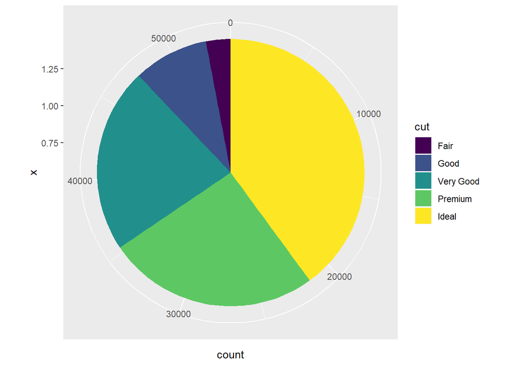

```r
ggplot(diamonds)+geom_bar(aes(x=1, fill=cut))+coord_polar(theta='y')
```

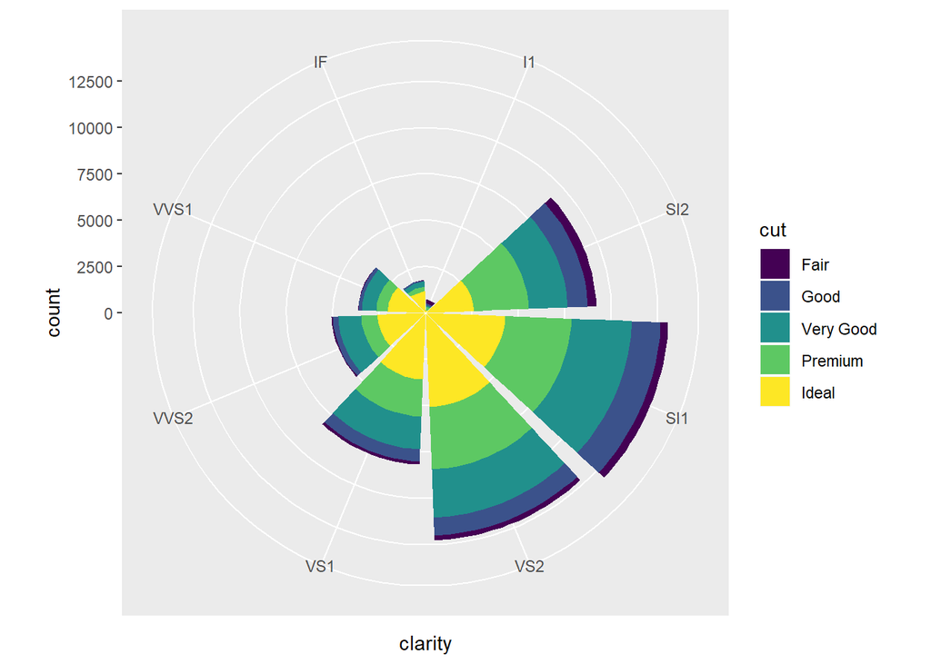

```r
ggplot(diamonds)+geom_bar(aes(x=clarity, fill=cut))+coord_polar()
```

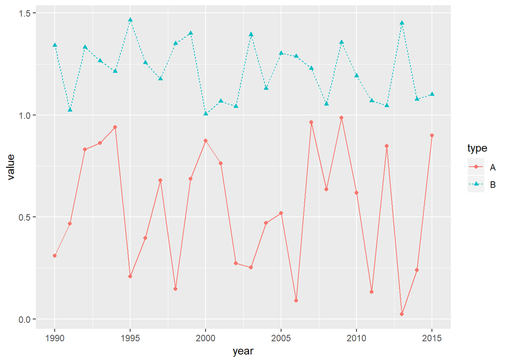

```r
year <- rep(1990:2015, times = 2)
type <- rep(c('A','B'),each = 26)
value <- c(runif(26),runif(26, min = 1,max = 1.5))
df <- data.frame(year = year, type = type, value = value)
ggplot(df, aes(x = year, y = value, linetype = type, colour = type, shape = type, fill = type))+ geom_line() + geom_point()
```

### 图形进阶

#### 直方图与密度曲线

做动图（没做出来）

install_github(“devtools”) Set path of Rtools Sys.setenv(PATH = paste(Sys.getenv(“PATH”), “*InstallDirectory*/Rtools/bin/”, “*InstallDirectory*/Rtools/mingw_64/bin”, sep = “;”)) #for 64 bit version Sys.setenv(BINPREF = “*InstallDirectory*/Rtools/mingw_64/bin”)

library(devtools) Manually “force” version to be accepted assignInNamespace(“version_info”, c(devtools:::version_info, list(“3.5” = list(version_min = “3.3.0”, version_max = “99.99.99”, path = “bin”))), “devtools”) find_rtools() # is TRUE now Now you can install gganimate devtools::install_github(“thomasp85/gganimate”)  
参考文献：商业分析Business Analytics  
https://mp.weixin.qq.com/s/BudZ_l7NKnYJ6lvbx-6Zlw

```r
library(ggplot2)
library(devtools)
#install_github("guhjy/easyGgplot2")
#library(easyGgplot2)
library(grid)

p <- ggplot(mpg,aes(hwy))
p1<-p + geom_histogram(position = 'identity',alpha=0.5,aes(y = ..density..,fill =factor(year))) +stat_density(geom = 'line',aes(colour = factor(year)))

pdf("compare_identity.pdf")

grid.newpage()

p2<-p + geom_histogram(alpha=0.5,aes(y = ..density..,fill =factor(year))) +stat_density(geom = 'line',aes(colour = factor(year)))

pushViewport(viewport(layout=grid.layout(2,1)))

vplayout<-function(x,y)
  viewport(layout.pos.row=x,layout.pos.col=y)

print(p1,vp=vplayout(1,1))
print(p2,vp=vplayout(2,1))
dev.off()
```

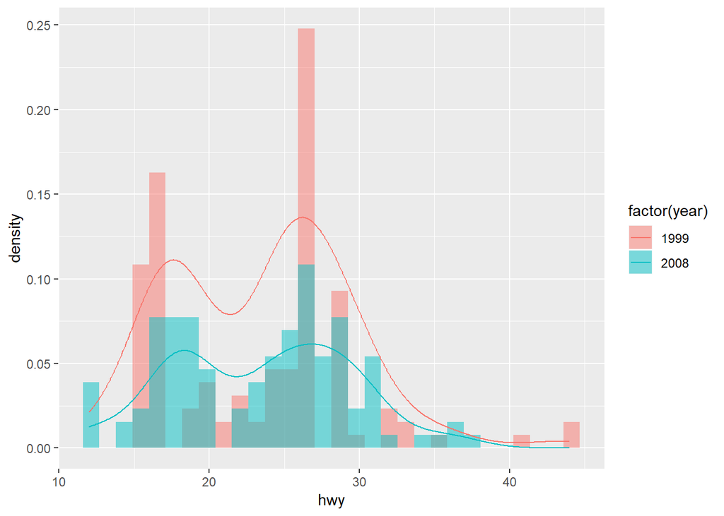

```r
p1
```

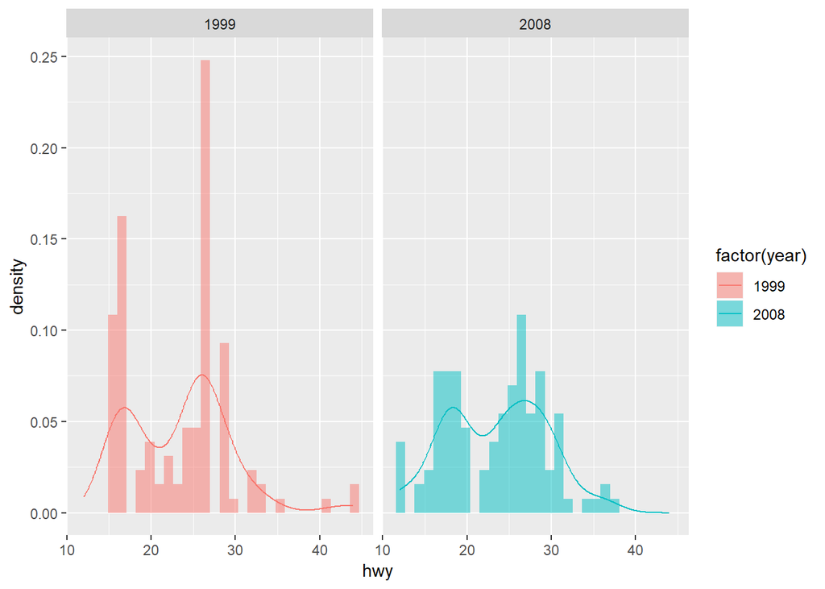

```r
p2<-p1+facet_wrap(~factor(year))

p2
```

### 曲线

```r
library(lubridate)
```

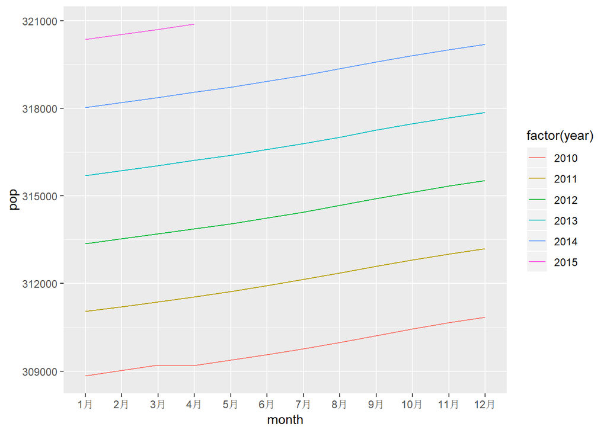

```r
economics$year<-year(economics$date)

economics$month<-month(economics$date,label=TRUE)

econ2000<-economics[which(economics$year>=2010),]

g<-ggplot(econ2000,aes(x=month,y=pop))

g<-g+geom_line(aes(color=factor(year),group=year))


g
```

### 多边形的绘制

```r
randnorm<-rnorm(30000)
randdensity<-dnorm(randnorm)
p<-ggplot(data.frame(x=randnorm,y=randdensity))+aes(x=x,y=y)+geom_point()+labs(x="Randnorm Normal Variables",y="Density")#数据化格式
negpos1seq<-seq(from=-1,to=1,by=0.1)
negto1<-data.frame(x=negpos1seq,y=dnorm(negpos1seq))

negto1<-rbind(c(min(negto1),0),negto1,c(max(negto1$x),0))
head(negto1)
```

```
##      x         y
## 1 -1.0 0.0000000
## 2 -1.0 0.2419707
## 3 -0.9 0.2660852
## 4 -0.8 0.2896916
## 5 -0.7 0.3122539
## 6 -0.6 0.3332246
```

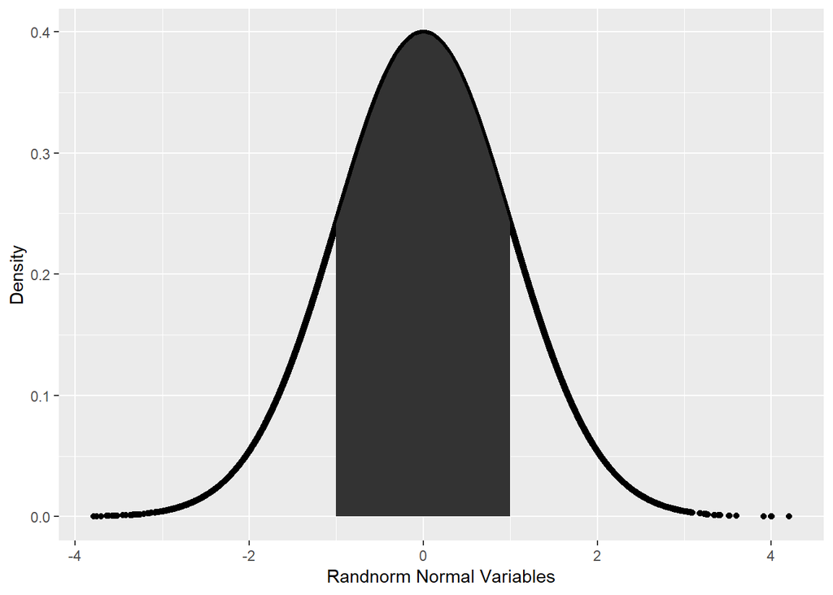

```r
p+geom_polygon(data=negto1,aes(x=x,y=y))
```

### 气泡散点图

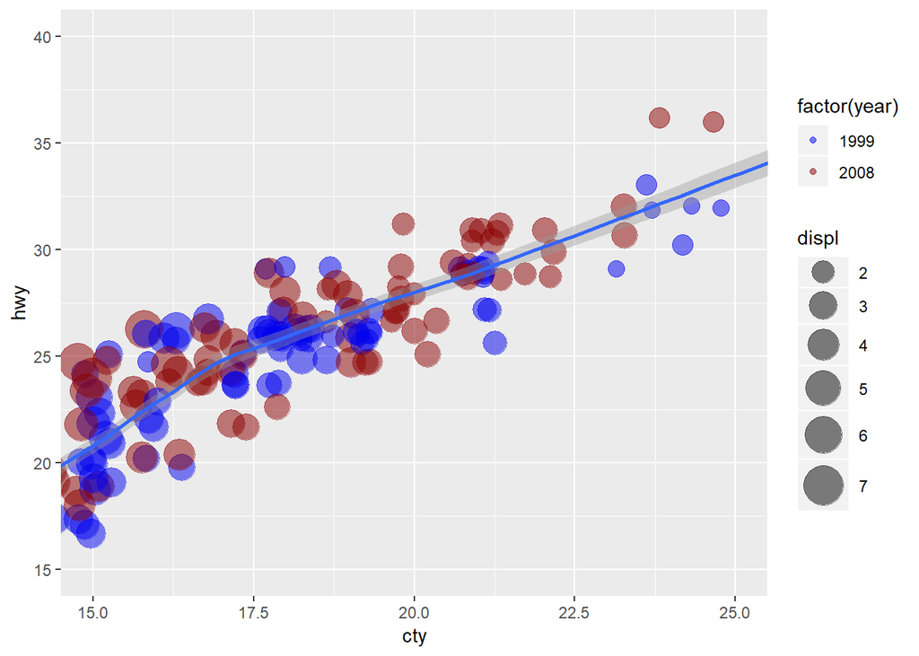

```r
#bmp(filename="output.bmp")
p <- ggplot(mpg, aes(x=cty,y=hwy))
p + geom_point(aes(colour=factor(year),size=displ),alpha=0.5,position = "jitter")+ stat_smooth()+scale_color_manual(values =c('blue2','red4'))+
scale_size_continuous(range = c(4, 10))+coord_cartesian(xlim = c(15, 25),ylim=c(15,40))
```

```r
#dev.off()
```

### 主题

ggthemes是ggplot2的一个扩展包，提供一些额外的themes、geoms、scales。加载该包主要作用是ggthemes提供的themes可以让我们快速画出不同背景图片。总结一下ggtheme的theme类型，方便下次快速调用。

themes 主题名 描述 theme_base 类似于 ggplot 默认设置 theme_calc 类似 LibreOffice Calc 图表 theme_economist 类似经济类图表 theme_economist_white 类似经济类图表 theme_excel 类似经典excel图表 theme_few 简洁型 theme_fivethirtyeight 类似于 http://fivethirtyeight.com的图 theme_foundation 这个主题的设计是为了基础建立新的主题,而不是直接使用。theme_foundation是一个完整的主题,只有最小的元素定义。它相比于theme_gray或theme_bw更容易通过扩展创建新的主题,因为那些主题和有着较深层次的主题定义。 theme_gdocs 类似默认的 Google Docs Chart theme_hc Highcharts JS theme_igary 主题与白色面板和灰色背景。 theme_map 一个简洁的地图主题 theme_pander pander的默认主题 theme_solarized 可以看 http://ethanschoonover.com/solarized 的介绍 theme_solarized_2 同上 theme_solid 主题删除所有non-geom元素(线条、文本等),这个主题只有所需的几何对象。 theme_stata 基于 Stata graph schemes的主题 theme_tufte 基于数据墨水最大化和图形设计的Edward Tufte 定量信息的视觉显示。没有边界,没有轴线,没有网格。这个主题与geom_rug或geom_rangeframe结合效果最好。 theme_wsj Wall Street Journal theme

```r
library(grid)
require(ggthemes)
```

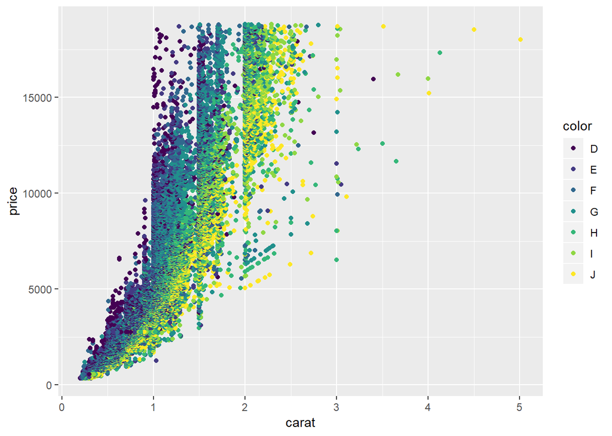

```r
g<-ggplot(diamonds,aes(x=carat,y=price))+geom_point(aes(color=color))
g
```

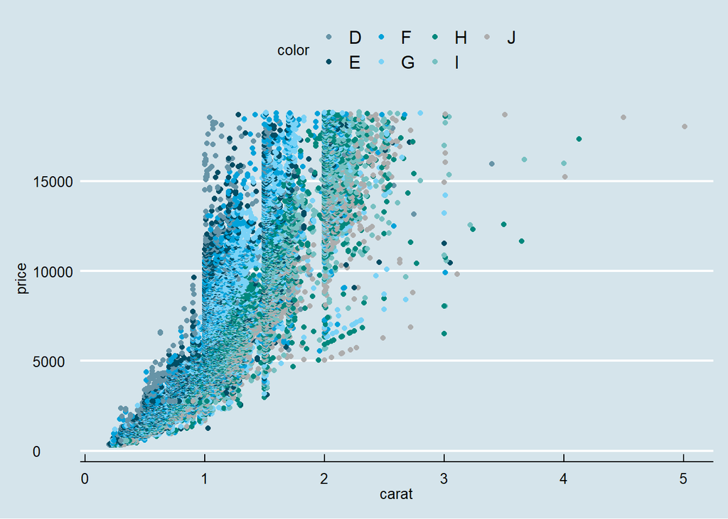

```r
g1<-g+theme_economist()+scale_colour_economist()

g2<-g+theme_excel()+scale_colour_excel()

g3<-g+theme_wsj()

g1
```

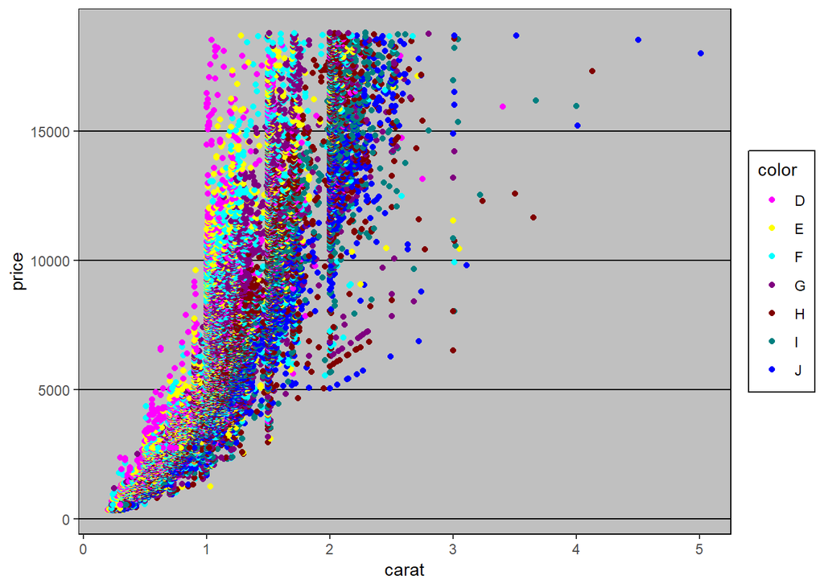

```r
g2
```

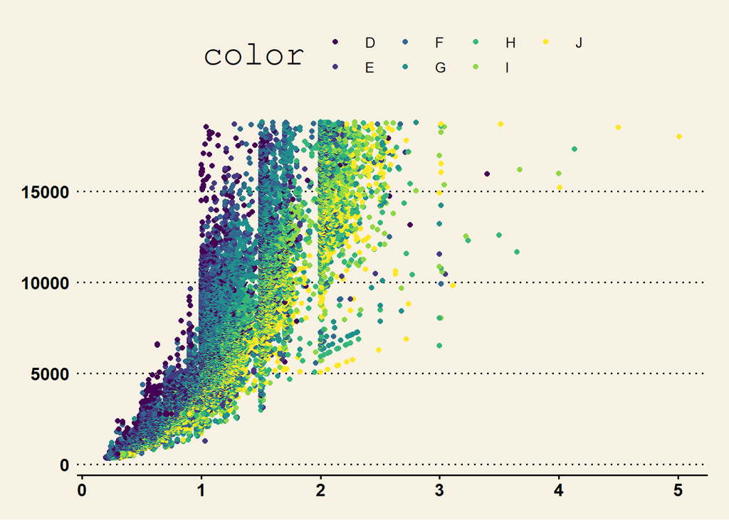

```r
g3
```

```r
data(tips,package="reshape2")
head(tips)
```

```
##   total_bill  tip    sex smoker day   time size
## 1      16.99 1.01 Female     No Sun Dinner    2
## 2      10.34 1.66   Male     No Sun Dinner    3
## 3      21.01 3.50   Male     No Sun Dinner    3
## 4      23.68 3.31   Male     No Sun Dinner    2
## 5      24.59 3.61 Female     No Sun Dinner    4
## 6      25.29 4.71   Male     No Sun Dinner    4
```

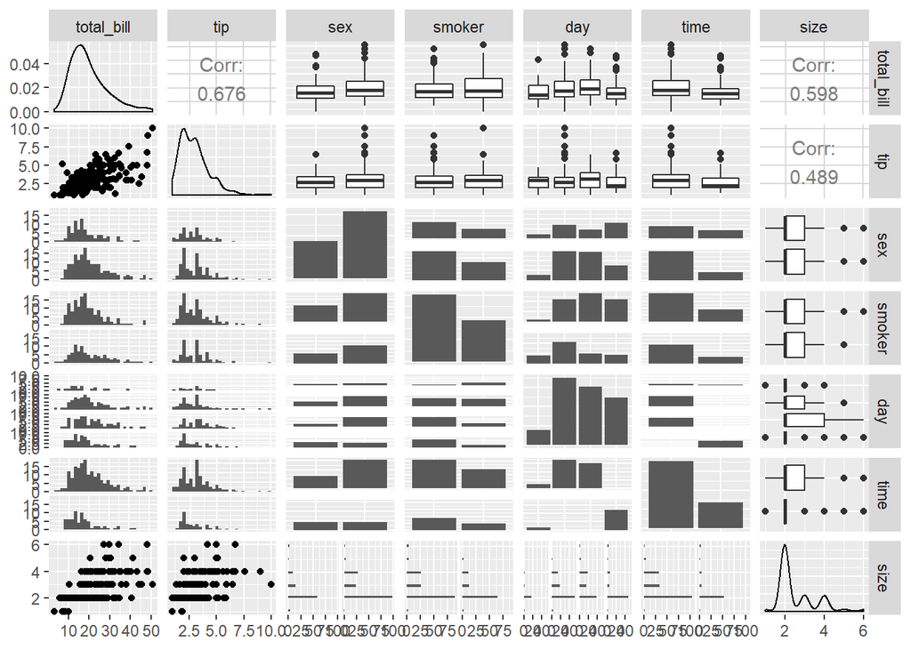

```r
GGally::ggpairs(tips)
```

```r
ggsave("graph.pdf", width=10, height=10,limitsize = FALSE)
```

参考文献网址：  
关于ggplot2包的基本功能介绍(上） - 知乎  
https://zhuanlan.zhihu.com/p/26637127  
关于ggplot2包的基本功能介绍(下） - 知乎  
https://zhuanlan.zhihu.com/p/26638832  
R—-ggplot2包介绍学习 - Little_Rookie - 博客园  
https://www.cnblogs.com/nxld/p/6059603.html